# statintro_final_Amit_Ziv.Rmd

2022-05-12

## Intro to Statistics and Data Analysis with R - Final Project - Ziv Barel & Amit Carsenti

## import libraries

We used the following libraries:

1. readr
2. tidyverse
3. tidytuesdayR
4. dplyr
5. ggplot2
6. measurements
7. gridExtra
8. BSDA
9. scales
10. corrplot

## Background

In this markdown we will analyze Coffee Ratings data set. The data set we are working with provide information about coffee from different countries in the world. The data comes from Coffee Quality Database courtesy of Buzzfeed data scientist James LeDoux. There is data for the two most economically important varieties of coffee plants around the world - Arabica and Robusta. As it written in Wikipedia, almost 60% of the coffee produced worldwide is Arabica and the rest is Robusta. That data includes variety of scoring to the coffee beans (acidity, sweetness, balance, etc.)

Data Source - https://github.com/rfordatascience/tidytuesday/blob/master/data/2020/2020-07-07/readme.md

## Goals

The goal of this project is to demonstrate and practice the different elements we have been talking about, which are a part of most data analysis/data science projects.

we will focus on those parameters; 1. Final grade 2. different grades that effect the final grade (flavor, acidity, aftertaste, etc.) 3. harvest year 4. altitude

- we will try to find the parameters that that are strongly related to the final grade coffee beans gets (we will do that by create a linear regression)
- we will try to understand the relationship between the species and the final grade (by F test for the variances)

## Import, tidying and Exploring the data

```r
data <- readr::read_csv('https://raw.githubusercontent.com/rfordatascience/tidytuesday/master/data/2020/2020-07-07/coffee_ratings.csv')
class(data) # check the class of the data - Data Frame
```

```
## [1] "spec_tbl_df" "tbl_df"      "tbl"         "data.frame"
```

First we can see that our data has 1339 observations and 43 different columns (features). The data is already data frame, so it will be easy to work with and we don’t need to change it to data frame. In order to understand the data set we will check some information and visualizations.

As the first step of exploring the data, we will take look at the first 10 observations.

```r
head(data, 10)
```

```
## # A tibble: 10 x 43
##    total_cup_points species owner    country_of_orig~ farm_name lot_number mill
##               <dbl> <chr>   <chr>    <chr>            <chr>     <chr>      <chr>
##  1             90.6 Arabica metad p~ Ethiopia         "metad p~ <NA>       meta~
##  2             89.9 Arabica metad p~ Ethiopia         "metad p~ <NA>       meta~
##  3             89.8 Arabica grounds~ Guatemala        "san mar~ <NA>       <NA>
##  4             89   Arabica yidneka~ Ethiopia         "yidneka~ <NA>       wole~
##  5             88.8 Arabica metad p~ Ethiopia         "metad p~ <NA>       meta~
##  6             88.8 Arabica ji-ae a~ Brazil            <NA>     <NA>       <NA>
##  7             88.8 Arabica hugo va~ Peru              <NA>     <NA>       hvc
##  8             88.7 Arabica ethiopi~ Ethiopia         "aolme"   <NA>       c.p.~
##  9             88.4 Arabica ethiopi~ Ethiopia         "aolme"   <NA>       c.p.~
## 10             88.2 Arabica diamond~ Ethiopia         "tulla c~ <NA>       tull~
## # ... with 36 more variables: ico_number <chr>, company <chr>, altitude <chr>,
## #   region <chr>, producer <chr>, number_of_bags <dbl>, bag_weight <chr>,
## #   in_country_partner <chr>, harvest_year <chr>, grading_date <chr>,
## #   owner_1 <chr>, variety <chr>, processing_method <chr>, aroma <dbl>,
## #   flavor <dbl>, aftertaste <dbl>, acidity <dbl>, body <dbl>, balance <dbl>,
## #   uniformity <dbl>, clean_cup <dbl>, sweetness <dbl>, cupper_points <dbl>,
## #   moisture <dbl>, category_one_defects <dbl>, quakers <dbl>, color <chr>, ...
```

First we will check the type of each feature (column) in the data

```r
glimpse(data)
```

```
## Rows: 1,339
## Columns: 43
## $ total_cup_points      <dbl> 90.58, 89.92, 89.75, 89.00, 88.83, 88.83, 88.75,~
## $ species               <chr> "Arabica", "Arabica", "Arabica", "Arabica", "Ara~
## $ owner                 <chr> "metad plc", "metad plc", "grounds for health ad~
## $ country_of_origin     <chr> "Ethiopia", "Ethiopia", "Guatemala", "Ethiopia",~
## $ farm_name             <chr> "metad plc", "metad plc", "san marcos barrancas ~
## $ lot_number            <chr> NA, NA, NA, NA, NA, NA, NA, NA, NA, NA, NA, NA, ~
## $ mill                  <chr> "metad plc", "metad plc", NA, "wolensu", "metad ~
## $ ico_number            <chr> "2014/2015", "2014/2015", NA, NA, "2014/2015", N~
## $ company               <chr> "metad agricultural developmet plc", "metad agri~
## $ altitude              <chr> "1950-2200", "1950-2200", "1600 - 1800 m", "1800~
## $ region                <chr> "guji-hambela", "guji-hambela", NA, "oromia", "g~
## $ producer              <chr> "METAD PLC", "METAD PLC", NA, "Yidnekachew Dabes~
## $ number_of_bags        <dbl> 300, 300, 5, 320, 300, 100, 100, 300, 300, 50, 3~
```

[output cut: 30 more lines]

Our data includes strings and numbers only. there are a lot of feature we might won’t use them all, but in order to decide which features we want we need to understand the data better, in order to to that we will do the following steps;

1. check how many unique values each features get
2. check the ratio of NA’s values each feature has - if we will find out that there are features with a lot of NA’s we will remove them
3. remove features that might be difficult to understand - such as certification address & certification contact

```r
# find how many unique values each feature has
count_unique_values <- rapply(data, function(x) length(unique(x)))
count_unique_values
```

```
##      total_cup_points               species                 owner
##                   180                     2                   316
##     country_of_origin             farm_name            lot_number
##                    37                   572                   228
##                  mill            ico_number               company
##                   461                   848                   282
##              altitude                region              producer
##                   397                   357                   692
##        number_of_bags            bag_weight    in_country_partner
##                   131                    56                    27
##          harvest_year          grading_date               owner_1
##                    47                   567                   320
##               variety     processing_method                 aroma
##                    30                     6                    33
##                flavor            aftertaste               acidity
##                    35                    35                    31
##                  body               balance            uniformity
##                    33                    33                    10
##             clean_cup             sweetness         cupper_points
##                    11                    17                    42
##              moisture  category_one_defects               quakers
##                    23                    18                    12
##                 color  category_two_defects            expiration
##                     5                    38                   566
##    certification_body certification_address certification_contact
##                    26                    32                    29
##   unit_of_measurement   altitude_low_meters  altitude_high_meters
##                     2                   199                   199
##  altitude_mean_meters
##                   212
```

We would like to find the precentage of missing values in the data. and also for every feature. Data with high ratio of NA’s values will be hard to work with and analyze.

```r
# find the percentage of missing values

mean(is.na(data)) # find the percentage of missing values in the data
```

```
## [1] 0.06912482
```

```r
colMeans(is.na(data)) # find the percentage of missing values (NA's) by column
```

```
##      total_cup_points               species                 owner
##           0.000000000           0.000000000           0.005227782
##     country_of_origin             farm_name            lot_number
##           0.000746826           0.268110530           0.793876027
##                  mill            ico_number               company
##           0.235250187           0.112770724           0.156086632
##              altitude                region              producer
##           0.168782674           0.044062733           0.172516804
##        number_of_bags            bag_weight    in_country_partner
##           0.000000000           0.000000000           0.000000000
##          harvest_year          grading_date               owner_1
##           0.035100822           0.000000000           0.005227782
##               variety     processing_method                 aroma
##           0.168782674           0.126960418           0.000000000
##                flavor            aftertaste               acidity
##           0.000000000           0.000000000           0.000000000
##                  body               balance            uniformity
##           0.000000000           0.000000000           0.000000000
##             clean_cup             sweetness         cupper_points
##           0.000000000           0.000000000           0.000000000
##              moisture  category_one_defects               quakers
##           0.000000000           0.000000000           0.000746826
##                 color  category_two_defects            expiration
##           0.162808066           0.000000000           0.000000000
##    certification_body certification_address certification_contact
##           0.000000000           0.000000000           0.000000000
##   unit_of_measurement   altitude_low_meters  altitude_high_meters
##           0.000000000           0.171769978           0.171769978
##  altitude_mean_meters
##           0.171769978
```

Overall, there are 6.9% missing values in the data. By looking at the percentage of missing values in each column (feature) we can see that lot_number is the feature with the highest NA’s ratio (almost 80% of this column is non available), therefore we decided to remove this column. we also want to remove features that we think will be hard to deal with - certification address & certification contact. those features are hard to understand and we decide that they are not relevant for our models and questions. after exploring all the data we will remove all the features we found out that are not useful for us.

For now we would not deal with other features that has NA’s. We will try to understand some other features that are available in the data, by looking and their statistic summary, it will help us decide if we need to do some tranformations to those features or remove them.

```r
as.data.frame(table(data$species))
```

```
##      Var1 Freq
## 1 Arabica 1311
## 2 Robusta   28
```

As can be seen, most of the observations in the data (1311/1339) are Arabica coffee beans. This is almost 98% of the data. This fact might effect our results when we would like to check if there is any difference between the final grade each species gets (since the Arabica sample is huge while the Robusta sample is really small).

```r
as.data.frame(table(data$category_one_defects))
```

```
##    Var1 Freq
## 1     0 1137
## 2     1  101
## 3     2   38
## 4     3   18
## 5     4   16
## 6     5    9
## 7     6    3
## 8     7    3
## 9     8    1
## 10    9    1
## 11   10    4
## 12   11    1
## 13   12    1
## 14   15    1
## 15   20    1
## 16   23    1
## 17   31    2
## 18   63    1
```

We can see that the feature category_one_defects can get values between 0-12, 15,20,23,31,63, but most observations got value 0 (1137 observations), and few got values above 2.

```r
as.data.frame(table(data$category_two_defects))
```

```
##    Var1 Freq
## 1     0  373
## 2     1  207
## 3     2  182
## 4     3  134
## 5     4  118
## 6     5   73
## 7     6   44
## 8     7   41
## 9     8   29
## 10    9   23
## 11   10   21
## 12   11    8
## 13   12   13
## 14   13    9
```

[output cut: 24 more lines]

The range of the values the feature category_two_defects is much bigger than the range of the values category_one_defects get. Most observations got value between 0-4 (include). Since we don’t understand those features and we think they won’t be useful for us, we decide to remove them from the data.

```r
table(data$quakers)
```

```
##
##    0    1    2    3    4    5    6    7    8    9   11
## 1244   39   30    5    5    5    4    3    1    1    1
```

We also need to make sure that all the the observations in each feature are in the same measurement unit.

```r
as.data.frame(table(data$unit_of_measurement))
```

```
##   Var1 Freq
## 1   ft  182
## 2    m 1157
```

```r
toString(data$unit_of_measurement) # first we will convert this feature to string in order to compare it later
index <- data$unit_of_measurement == "ft" # create index for rows where unit of measurements is in ft
# now we will replace all the altitude features from ft to meters. we will find those observations by the index we had created above
data$altitude_high_meters[index] <- data$altitude_high_meters[index]/0.3048
data$altitude_low_meters[index] <- data$altitude_low_meters[index]/0.3048
data$altitude_mean_meters[index] <- data$altitude_mean_meters[index]/0.3048
# after convert all the relevant values to meters,  we can change all the measurement units to meters back
data$unit_of_measurement[index] <- "m"
```

Since we are interested to find if there are any differences between the years, we will look at the range of the harvest year we have in the data. By looking at the raw data we have seen that there are observation with month instead of year. We would like to remove those observations. Also, the original type of this feature is character and we would like to change it to a string.

```r
class(data$harvest_year) # check the original type of this feature - character
strtoi(data$harvest_year) # we will change the type of this feature to int - in that way observations with non numeric value will be changed to NA
sum(is.na(data$harvest_year)) # we will find out how many observations has NA value right now - only 47.
```

[output not shown]

We found out that after transformed this feature we left with 47 NA’s. After change all the values in the feature “harvest year” to int we would like to find the range of the years described in the data.

```r
data$harvest_year <- as.integer(data$harvest_year) # change the column to int type
summary(data$harvest_year) # find out some statistics of the variable
```

```
##    Min. 1st Qu.  Median    Mean 3rd Qu.    Max.    NA's
##    2010    2012    2013    2014    2015    2018     211
```

The earliest year described in the data is 2010 and the latest is 2018. The number of NA’S increased (beacuse there where strings like “2010-2011” and the changing the column to int type has changed them to NA’s).

We will find out how many different processing methods are described in the data

```r
as.data.frame(table(data$processing_method))
```

```
##                        Var1 Freq
## 1             Natural / Dry  258
## 2                     Other   26
## 3    Pulped natural / honey   14
## 4 Semi-washed / Semi-pulped   56
## 5              Washed / Wet  815
```

The most popular processing method for the beans described in this data is “Washed/Wet”.

#Remove columns

Now we will remove all the features we thought won’t be useful for us, and create our Final subset data, we will work with.

Except from the features we had decided to remove above, we will remove some other features from the following reasons;

1. mill - the features indicates the mill where the beans were produced. this features has high NA’s values ratio (23.52%) and a lot of possible values (461) so it will be hard to deal with and also not important for our questions.
2. expiration - Expiration date of the beans - it might be interesting to check if there is any relationship between the expiration date and some other features in the data, but since this feature has a lot of unique values (566), we decide to remove it.
3. ico_number - International Coffee Organization number - this feature has a lot of unique values (848), and therefore it will be hard to check if this feature has any relationship to the final grade (even tough we think that there is such a relation).
4. grading date - this feature has 567 unique values. it will be hard to check relation between the grades and this feature since there a lot of unique values, even though it might be interesting. this feature is also not so relevant for our questions.
5. producer - this feature has 692 unique values. it will be hard to check relation between the grades and this feature since there a lot of unique values and so many observations.
6. farm name - this feature has 572 unique values. it will be hard to check relation between the grades and this feature since there a lot of unique values and so many observations.
7. company & owner_1 & owner - we will remove those features from the same reasons we had decided to remove the “farm name” feature. there are 282 unique values for “company” feature and 320 unique values for “owner_1” feature, and 316 unique values for “owner” feature.
8. in country partner - indicades partner of the country. we don’t need this feature for our questions.
9. altitude - we will remove this cloumns since this is the range of the other altitude features.
10. bag_weight - We decided to remove the column since we won’t use it in our project.
11. number_of_bags - We decided to remove the column since we won’t use it in our project.
12. region - the region column is not helpful since we can’t compare and check the values duo to the lack of consistency.
13. unit_of_measurement - we transferred all the unit to be in m.
14. variety - the variety of the bean doesn’t add a new crucial information for our goals and analysis.

```r
# remove columns
cols_to_drop <- c("lot_number", "certification_address", "certification_contact", "category_one_defects", "category_two_defects", "mill", "expiration", "ico_number", "grading_date", "producer", "farm_name", "company", "owner_1", "owner", "quakers", "in_country_partner", "altitude", "bag_weight", "number_of_bags", "region", "unit_of_measurement", "variety")
final_data = data[,!(names(data) %in% cols_to_drop)]
```

Since there are some observations that got total cup point 0 we would like to remove them from the final data set we gonna work with so they wouldn’t divert the results.

```r
# if total cup points == 0, we would like to remove this row
final_data = final_data[!(final_data$total_cup_points == 0.00),]
```

We will look at the data once again in order to check all the transformations and changes above has worked correctly.

```r
head(final_data, 10)
```

```
## # A tibble: 10 x 21
##    total_cup_points species country_of_orig~ harvest_year processing_meth~ aroma
##               <dbl> <chr>   <chr>                   <int> <chr>            <dbl>
##  1             90.6 Arabica Ethiopia                 2014 Washed / Wet      8.67
##  2             89.9 Arabica Ethiopia                 2014 Washed / Wet      8.75
##  3             89.8 Arabica Guatemala                  NA <NA>              8.42
##  4             89   Arabica Ethiopia                 2014 Natural / Dry     8.17
##  5             88.8 Arabica Ethiopia                 2014 Washed / Wet      8.25
##  6             88.8 Arabica Brazil                   2013 Natural / Dry     8.58
##  7             88.8 Arabica Peru                     2012 Washed / Wet      8.42
##  8             88.7 Arabica Ethiopia                   NA <NA>              8.25
##  9             88.4 Arabica Ethiopia                   NA <NA>              8.67
## 10             88.2 Arabica Ethiopia                 2014 Natural / Dry     8.08
## # ... with 15 more variables: flavor <dbl>, aftertaste <dbl>, acidity <dbl>,
## #   body <dbl>, balance <dbl>, uniformity <dbl>, clean_cup <dbl>,
## #   sweetness <dbl>, cupper_points <dbl>, moisture <dbl>, color <chr>,
## #   certification_body <chr>, altitude_low_meters <dbl>,
## #   altitude_high_meters <dbl>, altitude_mean_meters <dbl>
```

Since we would like to test if there are any differences between the final grades coffee beans from different countries get, we will create two samples - coffee beans from the “East” and coffee beans from the “West”

```r
final_data = final_data%>%
  mutate(place = case_when(
    endsWith(country_of_origin, "mexico") ~ "West",
    endsWith(country_of_origin, "Colombia") ~ "West",
    endsWith(country_of_origin, "Guatemala") ~ "West",
    endsWith(country_of_origin, "Brazil") ~ "West",
    endsWith(country_of_origin, "United States (Hawaii)") ~ "West",
    endsWith(country_of_origin, "Costa Rica") ~ "West",
    endsWith(country_of_origin, "United States (Puerto Rico)") ~ "West",
    endsWith(country_of_origin, "United States") ~ "West",
    endsWith(country_of_origin, "El Salvador") ~ "West",
    endsWith(country_of_origin, "Haiti") ~ "West",
    endsWith(country_of_origin, "Honduras") ~ "West",
    endsWith(country_of_origin, "Peru") ~ "West",
    endsWith(country_of_origin, "Panama") ~ "West",
    endsWith(country_of_origin, "Ecuador") ~ "West",
    endsWith(country_of_origin, "Nicaragua") ~ "West",
    endsWith(country_of_origin, "Cote d?Ivoire") ~ "West",
    endsWith(country_of_origin, "Thailand") ~ "East",
    endsWith(country_of_origin, "India") ~ "East",
    endsWith(country_of_origin, "Laos") ~ "East",
    endsWith(country_of_origin, "Philippines") ~ "East",
    endsWith(country_of_origin, "Myanmar") ~ "East",
    endsWith(country_of_origin, "Indonesia") ~ "East",
    endsWith(country_of_origin, "Japan") ~ "East",
    endsWith(country_of_origin, "Papua New Guinea") ~ "East",
    endsWith(country_of_origin, "Vietnam") ~ "East",
    endsWith(country_of_origin, "China") ~ "East",
    endsWith(country_of_origin, "Tanzania, United Republic Of") ~ "East",
    endsWith(country_of_origin, "Zambia") ~ "East",
    endsWith(country_of_origin, "Uganda") ~ "East",
    endsWith(country_of_origin, "Mauritius") ~ "East",
    endsWith(country_of_origin, "Burundi") ~ "East",
    endsWith(country_of_origin, "Kenya") ~ "East",
    endsWith(country_of_origin, "Rwanda") ~ "East",
    endsWith(country_of_origin, "Ethiopia") ~ "East"
    ))
```

## visualizations

First we will look at the distribution of the bean’s origin country

```r
# create subset data with the number of observations from each country
country_vec = c(final_data %>%
  count(country_of_origin, sort = T,)%>%
  na.omit())
country_df<- data.frame(country_vec)
```

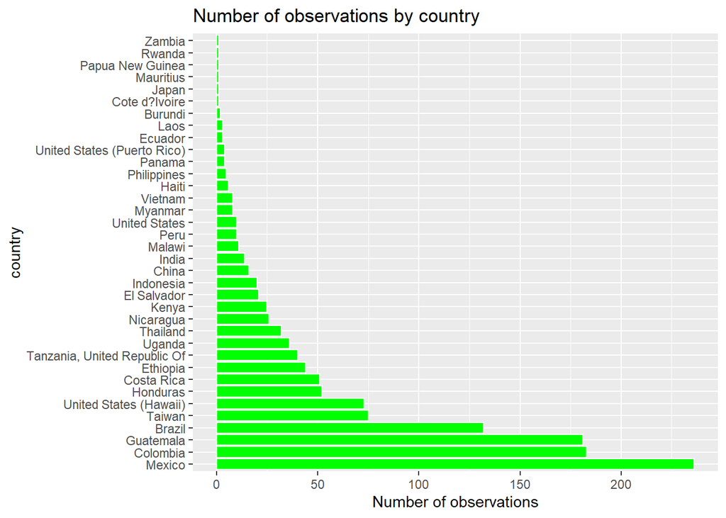

```r
# create plot for the number of observations from each country
ggplot(data = country_df, aes(x = n, y = reorder(country_of_origin, -n))) +
  geom_bar(stat = 'identity', colour = "white", fill = "green") +
  ggtitle("Number of observations by country") +
  xlab("Number of observations") +
  ylab("country")
```

We would like to see how the color of the bean is related to the total cup points

```r
color_data = final_data%>%
  filter(!is.na(color))%>%
  filter(color == c("Green", "Bluish-Green", "Blue-Green"))
mean_of_color = data.frame(aggregate(color_data$total_cup_points, list(color_data$color), FUN=mean))

mean_total = mean(final_data$total_cup_points)
```

```r
mean_of_color$diff <- mean_of_color$x-mean_total
```

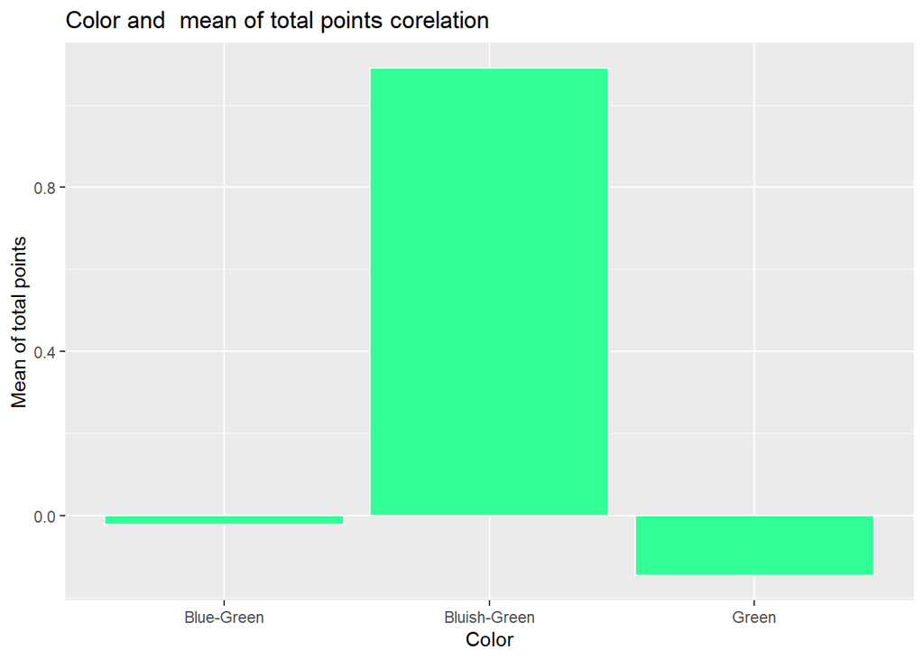

```r
  ggplot(data = mean_of_color, aes(x = Group.1, y = diff)) +
  geom_bar(stat = 'identity', colour = "white", fill = "#33FF99") +
  ggtitle("Color and  mean of total points corelation") +
  xlab("Color") +
  ylab("Mean of total points")
```

We can see that the Bullish-Green type of color gets on average 1.1 more points then the other types.

Now, We would like to show the difference between the number of observation from the west and the east

```r
# create a subset data with the number of observations from each part of the world
place_vec = c(final_data %>%
  count(place, sort = T,)%>%
  na.omit())
place_df<- data.frame(place_vec)
```

```r
blank_theme <-
  theme_minimal() +
  theme(
    axis.title.x = element_blank(),
    axis.title.y = element_blank(),
    panel.border = element_blank(),
    panel.grid = element_blank(),
    axis.ticks = element_blank(),
    plot.title = element_text(size=14, face="bold")
  )
```

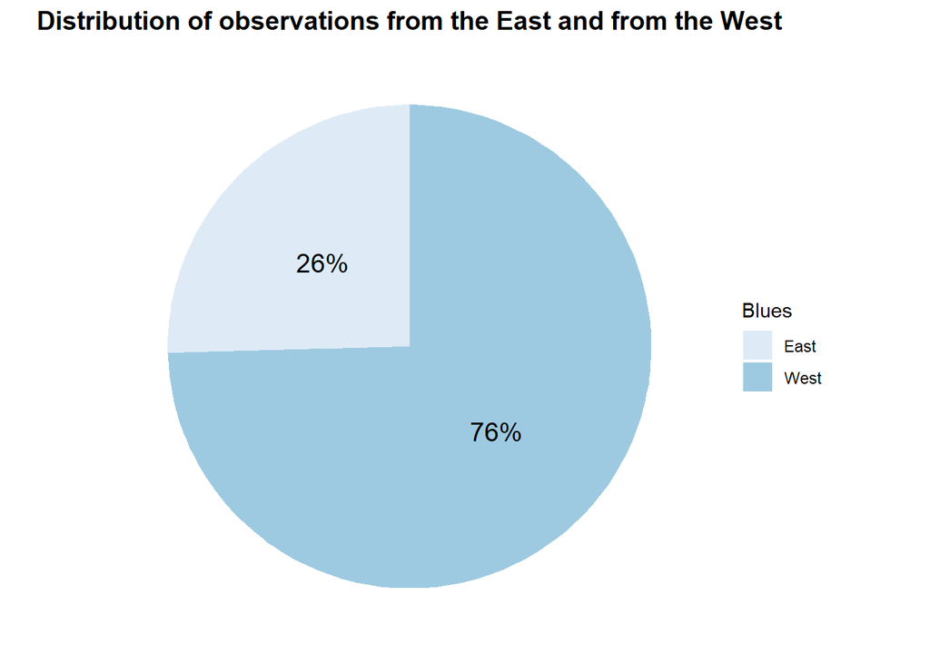

```r
# create pie chart to show how many observations we have from each part of the world
ggplot(data = place_df, aes(x = "", y =n, fill=place)) +
  geom_bar(stat = 'identity', width=1)+
  coord_polar("y", start=0)+
   theme_void() +
  blank_theme +
  scale_fill_brewer("Blues") +
  ggtitle("Distribution of observations from the East and from the West") +
  theme(plot.title = element_text(hjust=0.5)) +
  theme(axis.text.x = element_blank()) +
  geom_text(aes(y = n/2 + c(0, cumsum(n)[-length(n)]),
                label = percent(n/1000)), size=5)
```

Only 26% of the observations are from the “East”.

We would like to compare each specie and check the altitude it is growing

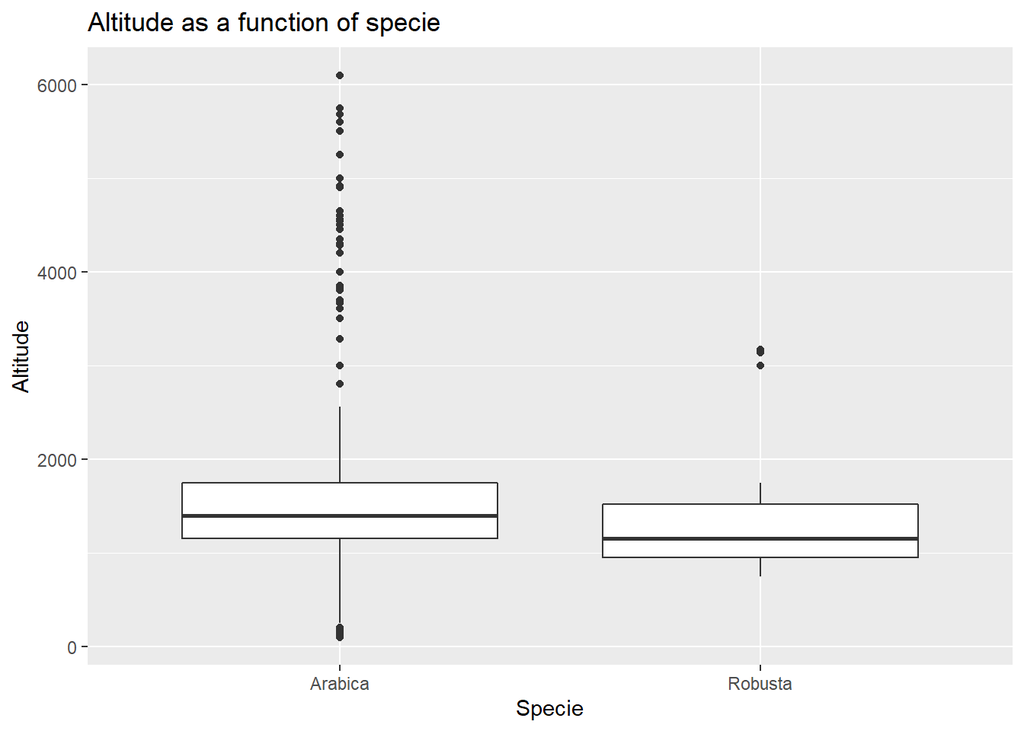

```r
height_plot_data = final_data%>%
  group_by(species)%>%
  select(altitude_mean_meters)
height_plot_data$altitude_mean_meters[height_plot_data$altitude_mean_meters < 100] <- 0
height_plot_data$altitude_mean_meters[height_plot_data$altitude_mean_meters > 6100] <- 0

height_plot_data = height_plot_data%>%
  na.omit()%>%
   filter(altitude_mean_meters != c(0))
ggplot(height_plot_data, aes(x=species, y=altitude_mean_meters)) +
  geom_boxplot()+
  ggtitle("Altitude as a function of specie") +
  xlab("Specie") +
  ylab("Altitude")
```

As you can see, on average, the Arabica specie grows at a higher altitude then the Robusta specie.

Since there are few process methods in the data we would like to find out how many observations there are in each processing method.

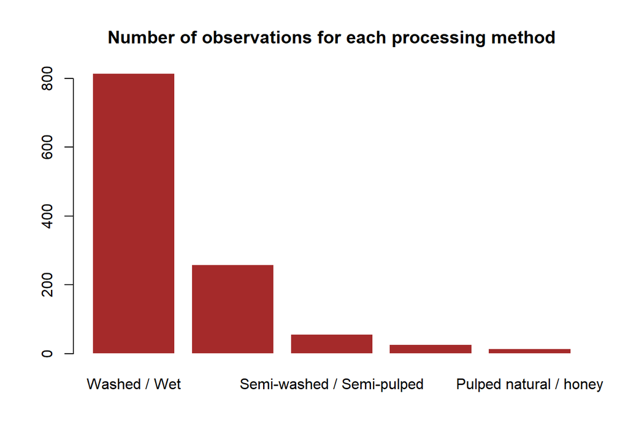

```r
# create a subset data to count how many observations there are for each processing method
process_sb <- c(final_data %>%
                  count(processing_method, sort=T,) %>%
                  na.omit())
process_df <- data.frame(process_sb)

# plot
barplot(process_sb$n, border = F, names.arg = process_df$processing_method,
        main = "Number of observations for each processing method",
        col = "Brown")
```

Lets look at the distribution of the feature total cup points

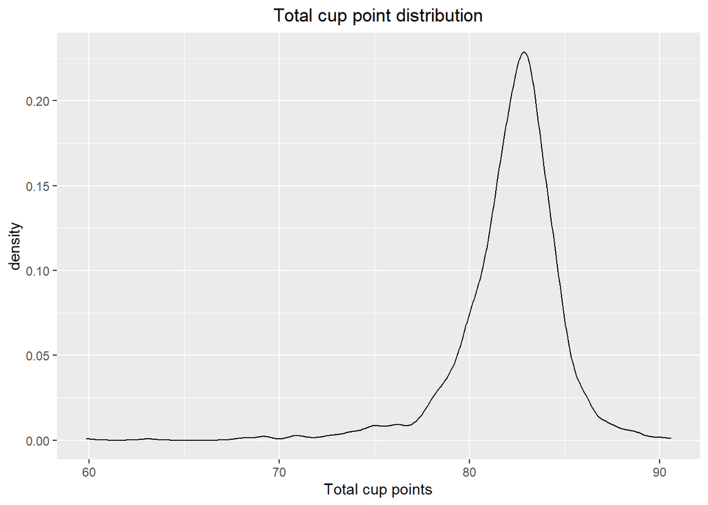

```r
ggplot(data = final_data, aes(x = total_cup_points )) +
  geom_density() +
  ggtitle("Total cup point distribution")+
  theme(plot.title = element_text(hjust=0.5)) +
  xlab("Total cup points")
```

```r
  ylab("Total cup points")
```

```
## $y
## [1] "Total cup points"
##
## attr(,"class")
## [1] "labels"
```

Before we test it by linear model, we would like to find out if there are differences in the final score between the different species. In order to that we will try to look at the boxplot of the final score by species

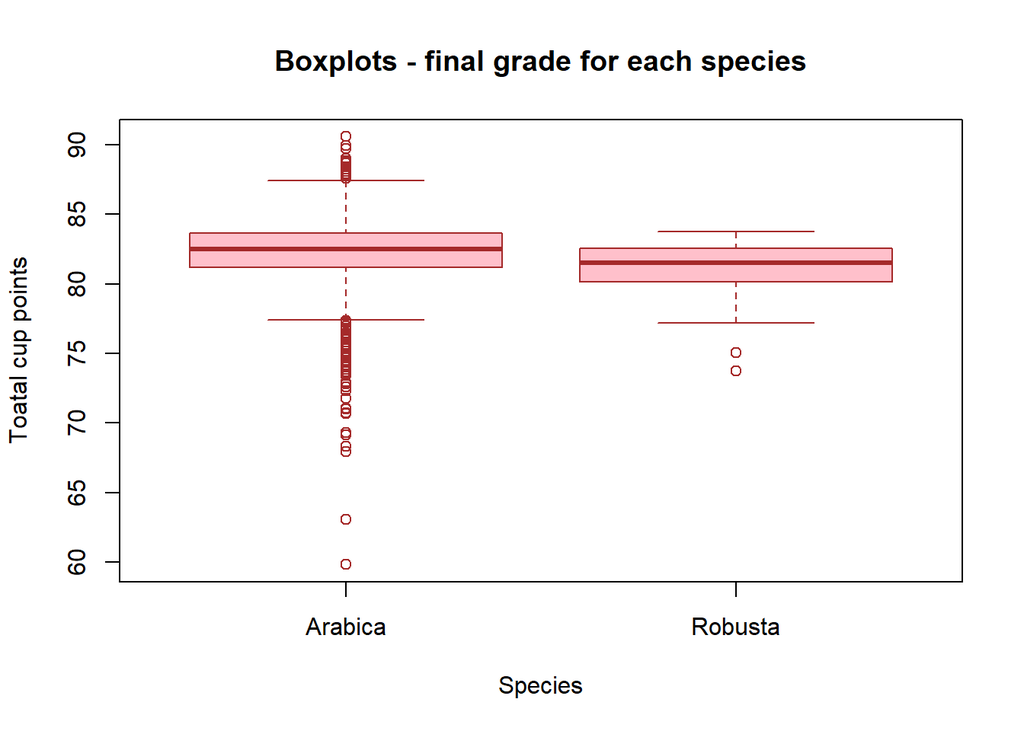

```r
# create subset data for final score by species
fc_species <- final_data %>%
  select(total_cup_points, species) %>%
  group_by(species)

# boxplot
boxplot(total_cup_points ~ species,
        data = fc_species,
        main = "Boxplots - final grade for each species",
        xlab = "Species",
        ylab = "Toatal cup points",
        col = "pink",
        border = "brown")
```

we would like to find out how many outliers there are for Arabica’s coffee beans total grade

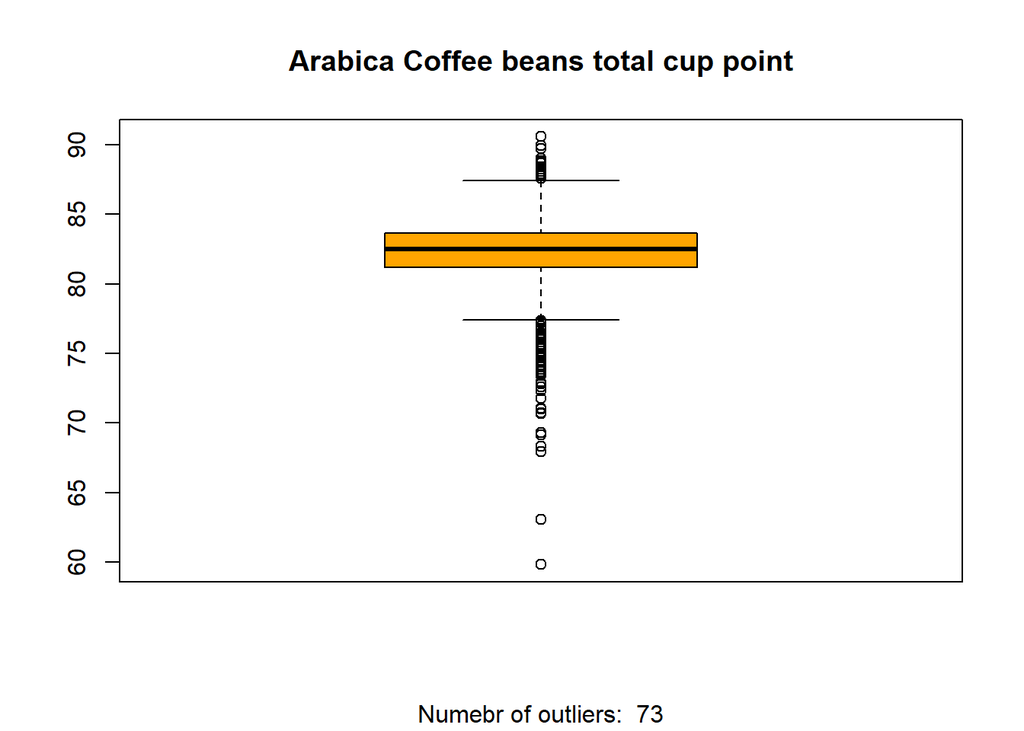

```r
fc_arabica <- subset(fc_species, species=="Arabica")
arabica_fc_outliers <- boxplot(fc_arabica$total_cup_points, plot = F)$out
arabica_fc_outliers <- length(arabica_fc_outliers)
boxplot(fc_arabica$total_cup_points, col= "orange",
       main = "Arabica Coffee beans total cup point",
       sub = paste("Numebr of outliers: ",arabica_fc_outliers))
```

Scatter plot - processing method & total cup points

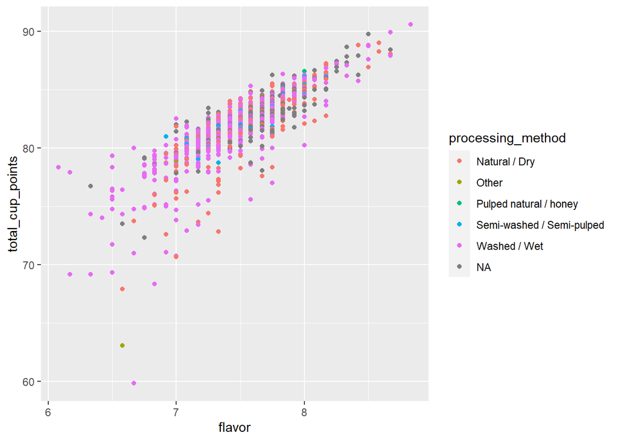

```r
ggplot(final_data, aes(x=flavor, y=total_cup_points, col=processing_method))+
  geom_point()
```

As can be seen in the scatter plot above, there are almost no observations of coffee beans that have been processed in any other way except of washed/net who got flavor grade less than 7. most observations processing method is washed/net

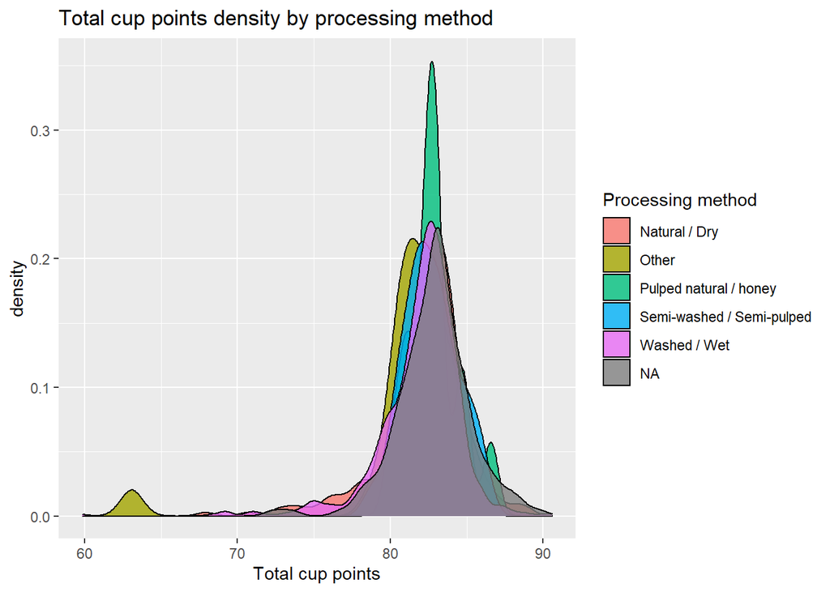

```r
ggplot(final_data, aes(total_cup_points)) +
  geom_density(aes(fill=processing_method), alpha=0.8) +
  labs(title = "Total cup points density by processing method",
       x = "Total cup points",
       fill = "Processing method")
```

The density of the final grade distribution is almost the same for all the different processing method, all of them are almost normal, except of the “other” processing method. in order to accurate more the differences in the final grade between the different processing method we will look at the boxplots

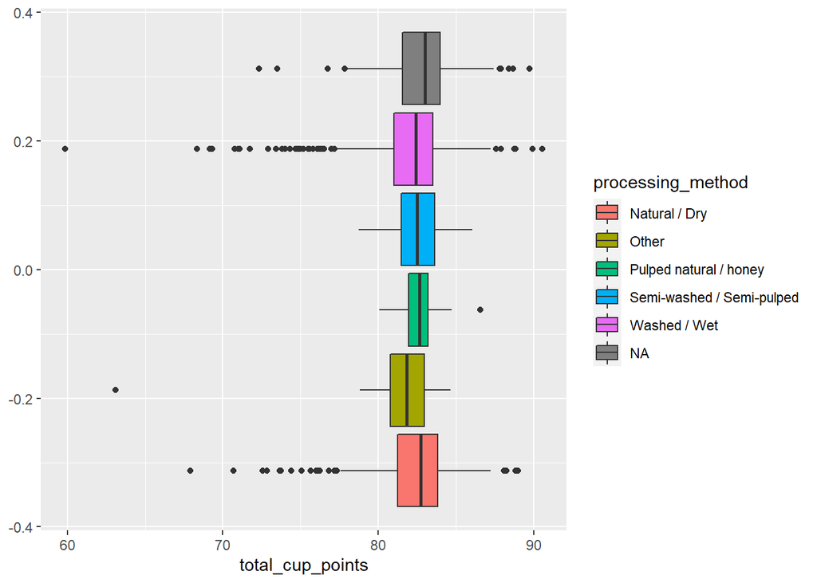

```r
ggplot(final_data, aes(total_cup_points)) +
  geom_boxplot(aes(varwidth = T, fill = processing_method))
```

plot to check the relation between certification body and the final grade

```r
unique(final_data$certification_body) # there are 26 different certifications body
```

```
##  [1] "METAD Agricultural Development plc"
##  [2] "Specialty Coffee Association"
##  [3] "Specialty Coffee Institute of Asia"
##  [4] "Ethiopia Commodity Exchange"
##  [5] "Almacafé"
##  [6] "Yunnan Coffee Exchange"
##  [7] "Blossom Valley International"
##  [8] "AMECAFE"
##  [9] "NUCOFFEE"
## [10] "Uganda Coffee Development Authority"
## [11] "Instituto Hondureño del Café"
## [12] "Specialty Coffee Association of Costa Rica"
## [13] "Kenya Coffee Traders Association"
## [14] "Africa Fine Coffee Association"
## [15] "Asociacion Nacional Del Café"
## [16] "Centro Agroecológico del Café A.C."
## [17] "Salvadoran Coffee Council"
## [18] "Specialty Coffee Association of Indonesia"
## [19] "Brazil Specialty Coffee Association"
## [20] "Asociación Mexicana De Cafés y Cafeterías De Especialidad A.C."
## [21] "Tanzanian Coffee Board"
## [22] "Central De Organizaciones Productoras De Café y Cacao Del Perú - Central Café & Cacao"
## [23] "Torch Coffee Lab Yunnan"
## [24] "Coffee Quality Institute"
## [25] "Asociación de Cafés Especiales de Nicaragua"
## [26] "Blossom Valley International\n"
```

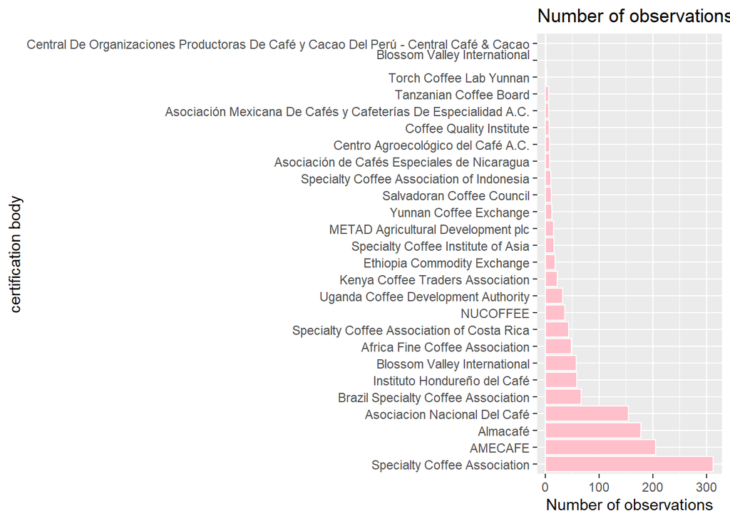

```r
# now we will find how many observations related to each certification body
certification_vec = c(final_data %>%
  count(certification_body, sort = T,)%>%
  na.omit())
certification_df<- data.frame(certification_vec)

# create pie char
ggplot(data = certification_df, aes(x = n, y = reorder(certification_df$certification_body, -n))) +
  geom_bar(stat = 'identity', colour = "white", fill = "pink") +
  ggtitle("Number of observations by certification_body") +
  xlab("Number of observations") +
  ylab("certification body")
```

as can be seen there are only few observations that are related to some certification bodies. The most popular certification bodies in the data are specialty coffee association, AMECAFE, almacafe and Association Nacional Del Cafe. we will check if there are any diffrences in the final grades distribution between the top 4 certification bodies.

```r
# create vector with the most popular certification bodies in the data
top_4_cb <- c("Specialty Coffee Association", "AMECAFE", "Almacafé", "Asociacion Nacional Del Café")

# create subset data for those certification bodies
certification_fg <- final_data %>%
  filter(certification_body %in% top_4_cb)
```

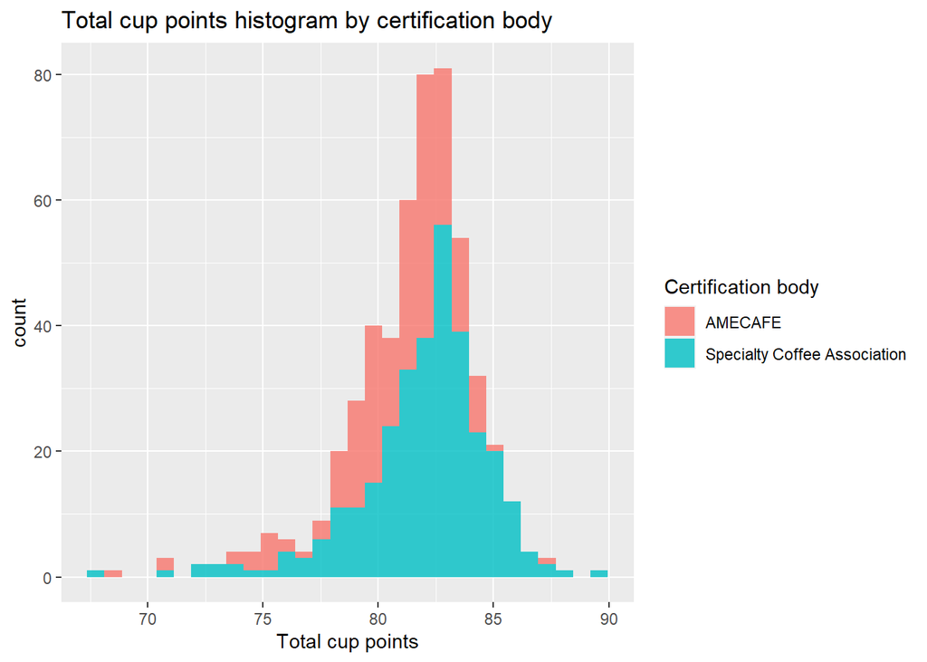

```r
ggplot(certification_fg, aes(total_cup_points)) +
  geom_histogram(aes(fill=certification_body), alpha=0.8) +
  labs(title = "Total cup points histogram by certification body",
       x = "Total cup points",
       fill = "Certification body")
```

plot to check if there is any correlation between the harvest year and the final grade

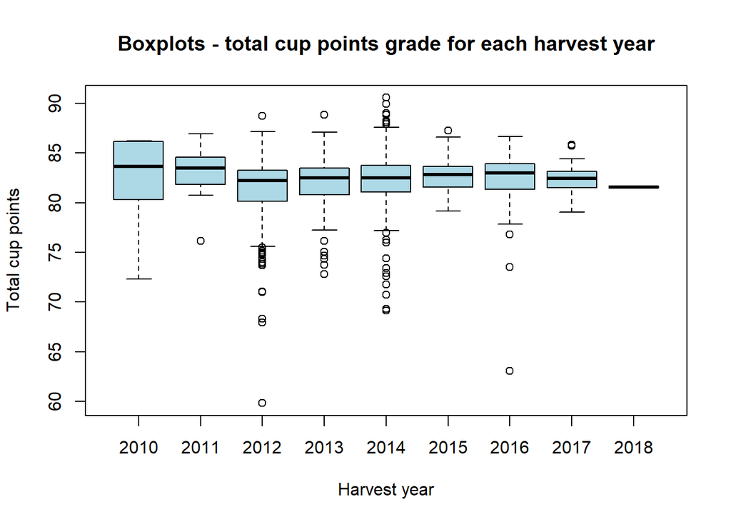

```r
boxplot(total_cup_points~harvest_year,
       data = final_data,
       main = "Boxplots - total cup points grade for each harvest year",
       xlab = "Harvest year",
       ylab = "Total cup points",
       col = "lightblue",
       fill = "white")
```

As can be seen in the boxplots, the mean of total cup points was the highest for observations from harvest year of 2010. also the Interquartile for the total cup points is the largest for that year (2010). there are a lot of outliers in observations from harvest year 2012 and 2014. Just from the boxplots, ee might think that observations from harvest year - 2010 are more likely to get higher total cup points values.

We would like to find out the distribution of each parameter that effect the final grade

```r
# first we will define a list with all the relevant features
final_grade_parameters <- c("aroma", "flavor", "aftertaste", "acidity", "body", "balance", "uniformity", "clean_cup", "sweetness", "cupper_points", "moisture")

# we will create a subset data with the relevant features
grades_data <- final_data %>%
  select(final_grade_parameters)
```

```
## Note: Using an external vector in selections is ambiguous.
## i Use `all_of(final_grade_parameters)` instead of `final_grade_parameters` to silence this message.
## i See <https://tidyselect.r-lib.org/reference/faq-external-vector.html>.
```

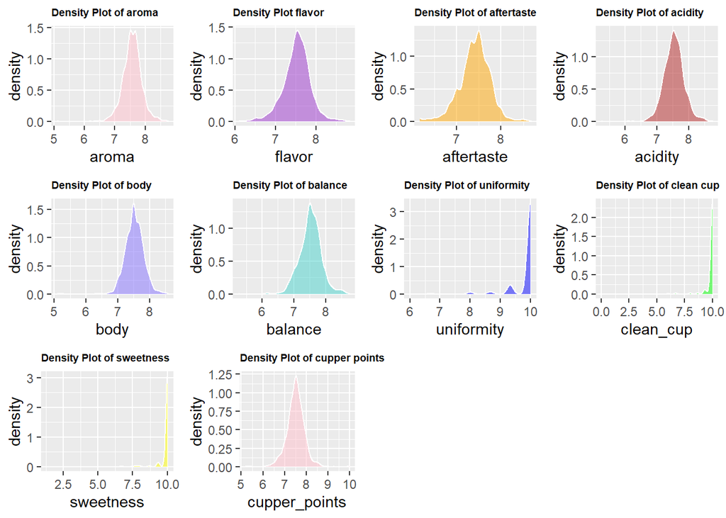

```r
# now we will plot the distribution of each column in the subset data
density_aroma <- ggplot(data=grades_data, aes(aroma)) + geom_density(col="white",fill="pink", alpha=0.5) + ggtitle("Density Plot of aroma") + theme(plot.title = element_text(size = 7, face = "bold"))
density_flavor <- ggplot(data=grades_data, aes(flavor)) + geom_density(col="white", fill="darkorchid", alpha=0.5) + ggtitle("Density Plot flavor") + theme(plot.title = element_text(size = 7, face = "bold"))
density_aftertaste <- ggplot(data=grades_data, aes(aftertaste)) + geom_density(col="white", fill="orange", alpha=0.5) + ggtitle("Density Plot of aftertaste")+ theme(plot.title = element_text(size = 7, face = "bold"))
density_acidity <- ggplot(data=grades_data, aes(acidity)) + geom_density(col="white", fill="firebrick", alpha=0.5) + ggtitle("Density Plot of acidity") +theme(plot.title = element_text(size = 7, face = "bold"))
density_body <- ggplot(data=grades_data, aes(body)) + geom_density(col="white", fill="slateblue1", alpha=0.5) + ggtitle("Density Plot of body") +theme(plot.title = element_text(size = 7, face = "bold"))
density_balance <- ggplot(data=grades_data, aes(balance)) + geom_density(col="white", fill="mediumturquoise", alpha=0.5) + ggtitle("Density Plot of balance") +theme(plot.title = element_text(size = 7, face = "bold"))
density_uniformity <- ggplot(data=grades_data, aes(uniformity)) + geom_density(col="white", fill="blue", alpha=0.5) + ggtitle("Density Plot of uniformity") +theme(plot.title = element_text(size = 7, face = "bold"))
density_clean_cup <- ggplot(data=grades_data, aes(clean_cup)) + geom_density(col="white", fill="green", alpha=0.5) + ggtitle("Density Plot of clean cup") +theme(plot.title = element_text(size = 7, face = "bold"))
density_sweettness <- ggplot(data=grades_data, aes(sweetness)) + geom_density(col="white", fill="yellow", alpha=0.5) + ggtitle("Density Plot of sweetness")+theme(plot.title = element_text(size = 7, face = "bold"))
density_cupper_points <- ggplot(data=grades_data, aes(cupper_points)) + geom_density(col="white", fill="pink", alpha=0.5) + ggtitle("Density Plot of cupper points") +theme(plot.title = element_text(size = 7, face = "bold"))
density_moisture <- ggplot(data=grades_data, aes(moisture)) + geom_density(col="white", fill="red", alpha=0.2) + ggtitle("Density Plot of moisture")+theme(plot.title = element_text(size = 7, face = "bold"))

grid.arrange(density_aroma, density_flavor, density_aftertaste, density_acidity, density_body, density_balance, density_uniformity, density_clean_cup,
             density_sweettness, density_cupper_points, ncol=4)
```

We will create a correlation matrix in order to find out if there are some parameters of the final grade that are strongly correlated with other parameters

```r
cor_mat <- cor(grades_data) # create correlation matrix
round(cor_mat, 2) # take only two digits after the point
```

```
##               aroma flavor aftertaste acidity  body balance uniformity
## aroma          1.00   0.74       0.69    0.61  0.53    0.60       0.14
## flavor         0.74   1.00       0.86    0.75  0.63    0.72       0.21
## aftertaste     0.69   0.86       1.00    0.72  0.63    0.75       0.21
## acidity        0.61   0.75       0.72    1.00  0.58    0.63       0.15
## body           0.53   0.63       0.63    0.58  1.00    0.67       0.08
## balance        0.60   0.72       0.75    0.63  0.67    1.00       0.21
## uniformity     0.14   0.21       0.21    0.15  0.08    0.21       1.00
## clean_cup      0.18   0.27       0.26    0.14  0.10    0.24       0.43
## sweetness      0.02   0.08       0.06    0.03  0.03    0.08       0.30
## cupper_points  0.60   0.74       0.73    0.61  0.52    0.65       0.19
## moisture      -0.15  -0.16      -0.20   -0.14 -0.17   -0.22       0.03
##               clean_cup sweetness cupper_points moisture
## aroma              0.18      0.02          0.60    -0.15
## flavor             0.27      0.08          0.74    -0.16
## aftertaste         0.26      0.06          0.73    -0.20
## acidity            0.14      0.03          0.61    -0.14
## body               0.10      0.03          0.52    -0.17
## balance            0.24      0.08          0.65    -0.22
## uniformity         0.43      0.30          0.19     0.03
## clean_cup          1.00      0.34          0.24    -0.01
## sweetness          0.34      1.00          0.03     0.09
## cupper_points      0.24      0.03          1.00    -0.19
## moisture          -0.01      0.09         -0.19     1.00
```

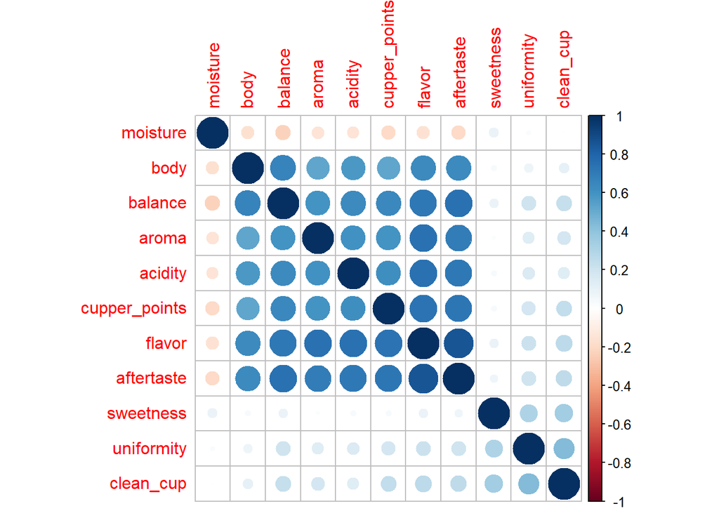

```r
corrplot(cor_mat, order = "hclust") # plot the correlation matrix
```

Now, when we are better understand our data and transformed it and clean it, we will test our hypothesis and run some models.

# Expected Value Test (Z.test)

Now we will perform an expected value test to check the hypotheses that the place has no affect on the grade.

$H0$: $μ$(East) = $μ$(West)

$H1$: $μ$(East) != $μ$(West)

Sigma is known and the number of observations are over 30 so we will use z.test. we will split our original data into two different data sets that will help us perform the test.

```r
east_ss =subset(final_data, place == "East")
west_ss = subset(final_data, place == "West")
sd_of_east = sd(east_ss$total_cup_points, na.rm = FALSE)
sd_of_west = sd(west_ss$total_cup_points, na.rm = FALSE)
```

Now we will declare that the independent variable is place while the dependent variable is the final grade. We chose to use the formula code due to the fact that we use to different data sets. we chose alpha to be 5% so our rejection regions are:

Z0> $μ$+$Z$ 0.975(df = n-1)* $σ^2$ ^2 /n^0.5

Z0< $μ$-$Z$ 0.975(df = n-1)* $σ^$ 2^2 /n^0.5

Now we will perform the test:

```r
z.test(east_ss$total_cup_points, west_ss$total_cup_points, alternative='two.sided', mu=0, sigma.x=sd_of_east, sigma.y=sd_of_west)
```

```
##
##  Two-sample z-Test
##
## data:  east_ss$total_cup_points and west_ss$total_cup_points
## z = 5.1041, p-value = 3.324e-07
## alternative hypothesis: true difference in means is not equal to 0
## 95 percent confidence interval:
##  0.5535151 1.2436087
## sample estimates:
## mean of x mean of y
##  83.13345  82.23489
```

As it is shown in the results we reject the main hypothesis which means that the mean of the the beans from the east and the beans from the west is not equal.

# S.D Test (Var.test)

Now we would like to check the hypothesis that the standard variation of both the grades of both areas (east and west) are the same. In order to do that we will use the F.test. We assume that the distribution of the sets are Normal due to the fact that we have more than 30 samples and that they are Independents. Our hypothesis:

$H0$: $σ^2$(East) = $σ^2$(West)

$H1$: $σ^2$(East) =! $σ^2$(West)

$σ^2$(East)^2 /$σ^2$(West)^2 < $F$(0.05)(n1-1,n2-1)

$σ^2$(East)^2 /$σ^2$(West)^2 > $F$(0.95)(n1-1,n2-1)

```r
var.test(east_ss$total_cup_points, west_ss$total_cup_points, alternative = "two.sided")
```

```
##
##  F test to compare two variances
##
## data:  east_ss$total_cup_points and west_ss$total_cup_points
## F = 0.73866, num df = 257, denom df = 756, p-value = 0.004077
## alternative hypothesis: true ratio of variances is not equal to 1
## 95 percent confidence interval:
##  0.6075050 0.9071852
## sample estimates:
## ratio of variances
##          0.7386617
```

As it is shown in the results we reject the main hypothesis which means that the sd of the the beans from the east and the beans from the west is not equal.

# goodness of fit

In order to check if the distribution of the total cup point is normal - we will do goodness of fit test (chi test).

before that, we will create qq-plot for the total cup points distribution. qqplot draws the sample versus the theoretical distribution.

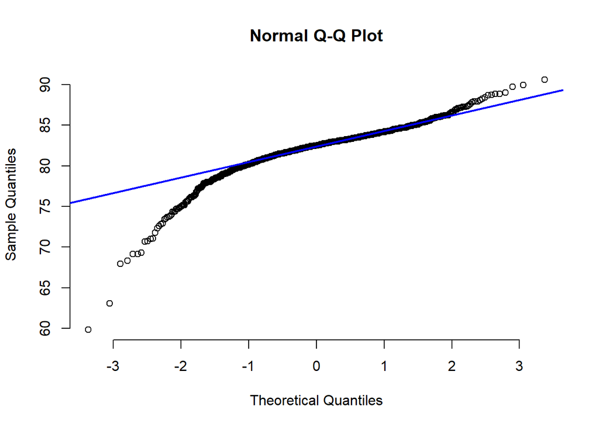

```r
qqnorm(final_data$total_cup_points, pch = 1, frame = FALSE)
qqline(final_data$total_cup_points, col = "blue", lwd = 2)
```

As can be seen from the qqplot, the distribution of the total cup points we have in our data is not exactly normal but really close to normal distribution.

Now we will do goodness of fit test in order to find out if the distribution is normal.

our hypothesis will be the following:

- $H0$: Total cup points ~ $N(μ,σ^2)$
- $H1$: else
- reject the hypothesis if: $\chi_0^2>\chi_{\alpha,k-p-1}^2$.

more specifically we would like to check the following hypothesis:

- $H0$: Total cup points ~ $N(82.1512,2.68)$
- $H1$: else

```r
# define interval breaks for the total cup points (according to the density plot)
total_cup_intervals <- c(60, 65, 70, 75, 80, 85, 90, 95, 100)
sample_size <- length(final_data$total_cup_points)

total_cup_dist <- final_data %>%
  mutate(grades_scale = cut(total_cup_points, breaks = total_cup_intervals))

tcp_mean <- mean(total_cup_dist$total_cup_points)
tcp_mean
```

```
## [1] 82.1512
```

```r
tcp_v <- sd(total_cup_dist$total_cup_points)
tcp_v
```

```
## [1] 2.686862
```

```r
total_cup_chi_prep <- total_cup_dist %>%
   count(grades_scale, name = "observed") %>%
   mutate(upper_bound = total_cup_intervals[-1]) %>%
   mutate(lower_bound = total_cup_intervals[1:8]) %>%
   mutate(expected_prob = pnorm(q = upper_bound, mean = tcp_mean, sd = tcp_v)-
             pnorm(q = lower_bound, mean = tcp_mean, sd = tcp_v)) %>%
   mutate(expected_prob =  expected_prob/sum(expected_prob)) %>%
   mutate(expected = expected_prob*500) %>%
   mutate(chi_comp = (observed-expected)^2/expected)
```

```r
chi_emp <- sum(total_cup_chi_prep$chi_comp)
chi_emp
```

```
## [1] 23109041
```

```r
qchisq(p = 1-0.05, df = 8-1-1) # rejection value
```

```
## [1] 12.59159
```

since $23109041=\chi^2_0>\chi^2_{1338, 6}=12.59$, we reject the null hypothesis. According to the test result we will assume that the total cup points distribution is not normal (with those parameters we have tested).

# Linear Regression Model

We would like to find out the relation between the final grade (total cup point) and all the other grades (include bag weight) that might effect the final grade, if this is a simple linear relationship and the final grade is the sum of all the parameters. we will do it by a linear regression.

The independent Variable - total cup point, and the dependent variables - aroma, flavor, aftertaste, acidity, body, balance, uniformity, clean_cup, sweetness, cupper_points, moisture.

```r
LinearModel <- lm(total_cup_points ~ aroma + flavor + aftertaste + acidity + body + balance + uniformity + clean_cup + sweetness + cupper_points + moisture, data = final_data)
```

```r
LinearModel
```

```
##
## Call:
## lm(formula = total_cup_points ~ aroma + flavor + aftertaste +
##     acidity + body + balance + uniformity + clean_cup + sweetness +
##     cupper_points + moisture, data = final_data)
##
## Coefficients:
##   (Intercept)          aroma         flavor     aftertaste        acidity
##    -0.0275229      1.0005840      0.9989279      1.0023758      0.9981810
##          body        balance     uniformity      clean_cup      sweetness
##     1.0011861      1.0025300      1.0028162      1.0004468      0.9991373
## cupper_points       moisture
##     0.9968137      0.0002271
```

as can be seen each parameter that have been tested, except of moisture is lineary related to the final grades. All the parameters that have been tested have been graded between 0-10, therefore if all the parameters got 10 the final grade will be 100.

It was expected that those parameters will be linear y correlated to the final grade.

```r
summary(LinearModel)
```

```
##
## Call:
## lm(formula = total_cup_points ~ aroma + flavor + aftertaste +
##     acidity + body + balance + uniformity + clean_cup + sweetness +
##     cupper_points + moisture, data = final_data)
##
## Residuals:
##      Min       1Q   Median       3Q      Max
## -0.49280 -0.00247 -0.00055  0.00838  0.09982
##
## Coefficients:
##                 Estimate Std. Error  t value Pr(>|t|)
## (Intercept)   -0.0275229  0.0159011   -1.731   0.0837 .
## aroma          1.0005840  0.0021250  470.864   <2e-16 ***
## flavor         0.9989279  0.0030179  330.996   <2e-16 ***
## aftertaste     1.0023758  0.0027498  364.526   <2e-16 ***
## acidity        0.9981810  0.0021828  457.288   <2e-16 ***
## body           1.0011861  0.0020521  487.891   <2e-16 ***
## balance        1.0025300  0.0021021  476.927   <2e-16 ***
## uniformity     1.0028162  0.0010373  966.750   <2e-16 ***
## clean_cup      1.0004468  0.0007273 1375.525   <2e-16 ***
## sweetness      0.9991373  0.0008665 1153.122   <2e-16 ***
## cupper_points  0.9968137  0.0016226  614.350   <2e-16 ***
## moisture       0.0002271  0.0094475    0.024   0.9808
## ---
## Signif. codes:  0 '***' 0.001 '**' 0.01 '*' 0.05 '.' 0.1 ' ' 1
##
## Residual standard error: 0.01608 on 1326 degrees of freedom
## Multiple R-squared:      1,  Adjusted R-squared:      1
## F-statistic: 3.394e+06 on 11 and 1326 DF,  p-value: < 2.2e-16
```

Lets look at some relations between the final grade and other parameters gear

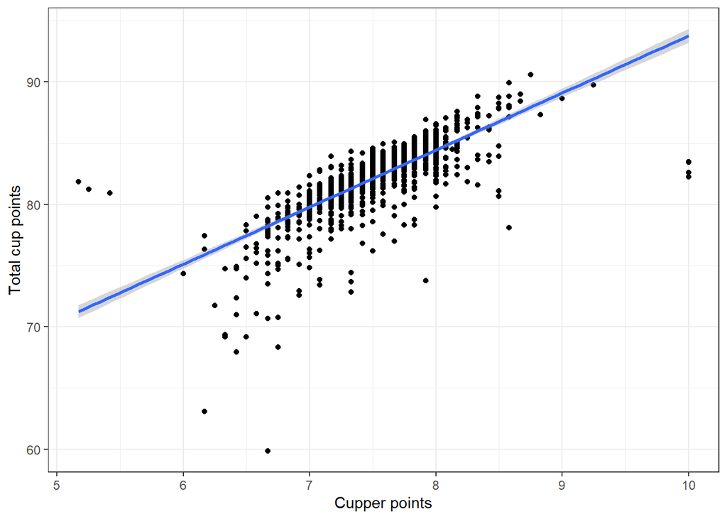

```r
ggplot(final_data, aes(x = cupper_points, y=total_cup_points)) +
  geom_point() + theme_bw() +
  stat_smooth(method="lm") + xlab("Cupper points") + ylab("Total cup points")
```

As can be seen most of the samples got cupper points between ~6 to ~9. and few got 10 or 5. there is a positive correlation between the cupper point and the total cup points.

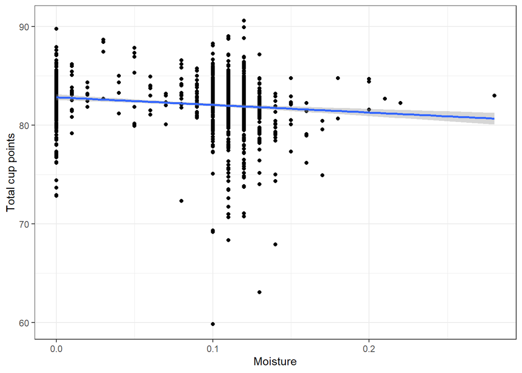

```r
ggplot(final_data, aes(x = moisture, y=total_cup_points)) +
  geom_point() + theme_bw() +
  stat_smooth(method="lm") + xlab("Moisture") + ylab("Total cup points")
```

[figure not shown]

```r
scatter.smooth(x=final_data$aroma, y=final_data$total_cup_points, main="Total cup points ~ sweetness")
```

We would like to find out how some other parameters (such as the species and the altitude) effect the final grade Since we believe the coffee beans species might effect the final grade, we would like to include this feature as a dummy variable in our regression

```r
# create a dummy variable for Arabica coffee beans. if coffee species is Arabica, dummy variable = 1, else = 0
final_data$Arabica <- ifelse(final_data$species == "Arabica", 1, 0)
# create a dummy variable for East. if coffee species is from country in the east, dummy variable = 1, else = 0
final_data$East <- ifelse(final_data$place == "East", 1, 0)
```

Now we will define another linear model, to check our hypothesis that the altitude and the species effect the final cup grade. The independent Variable - total cup point, and the dependent variables - altitude mean meters + Arabica (dummy variable) + East ( dummy variable)

```r
LinearModel2 <- lm(total_cup_points ~ altitude_mean_meters + Arabica + East, data = final_data)
```

Lets look at the regression results

```r
LinearModel2
```

```
##
## Call:
## lm(formula = total_cup_points ~ altitude_mean_meters + Arabica +
##     East, data = final_data)
##
## Coefficients:
##          (Intercept)  altitude_mean_meters               Arabica
##            8.069e+01            -1.136e-05             1.740e+00
##                 East
##            9.070e-01
```

Those results shows us that the mean altitude is not related to the final grade, but there is a positive correlation between Arabica species and the final grade. if the coffee beans are “Arabica” there final grade will 1.740 higher (if all the others parameters are equal). Also there is a positive correlation between “East” and the final grade. If the coffee beans are from the “East” the final grade will be 0.907 points higher.

```r
summary(LinearModel2)
```

[output not shown]

# Conclusion